# STAT508_DAA3

Ada Lazuli

2026-02-03

## Front Matter

```r
library(broom)
library(dplyr)
library(factoextra)
library(GGally)
library(ggplot2)
library(ggrepel)
library(gridExtra)
Pizza <- read.csv("../sample_data/L02_Pizza.csv")
```

## Problem 1 - Preparing for Clustering

### Part a. - Create a dataset with numeric variables and standardize

```r
PizzaScaled <- Pizza %>% select(mois, prot, fat, ash, sodium, carb, cal)
PizzaScaled <- scale(PizzaScaled, center = TRUE, scale = TRUE)
```

## Problem 2 - Performing K-means

### Part a. - Create elbow plot for K-means

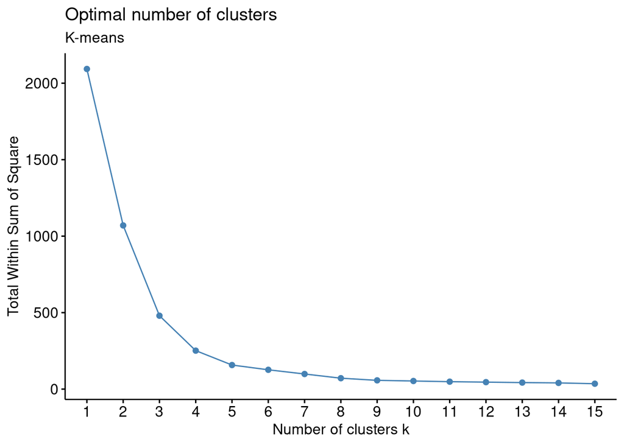

```r
set.seed(123)
fviz_nbclust(x = PizzaScaled, FUNcluster = kmeans,
             method = "wss", k.max = 15,
             nstart = 25,
             iter.max = 15) +
  labs(subtitle ="K-means")
```

### Part b. - How many clusters?

Based on the elbow plot, it seems reasonable to explore between 4 and 5 clusters. Based on the PCA plot, it could be argued that there are between 4 and 5 clusters.

Solely using the wss score, it definitely seems to level off after 5 clusters.

### Part c. - Perform K-means with K = 5 and extract Total Within Cluster Variation

```r
set.seed(123)

kmeansRes5c <-
  kmeans(x = PizzaScaled, centers = 5, nstart = 25, iter.max = 15)

kmeansRes5c$tot.withinss
```

```
## [1] 157.3249
```

The total within cluster variation is 157.3249302

### Part d. - How many observations were assigned to each cluster?

```r
table(kmeansRes5c$cluster)
```

```
##
##   1   2   3   4   5
##  61  29 120  31  59
```

The number of observations by cluster are:

1. 61 observations
2. 29 observations
3. 120 observations
4. 31 observations
5. 59 observations

### Part e. - Perform PCA and create visualization for K = 5 (K-means)

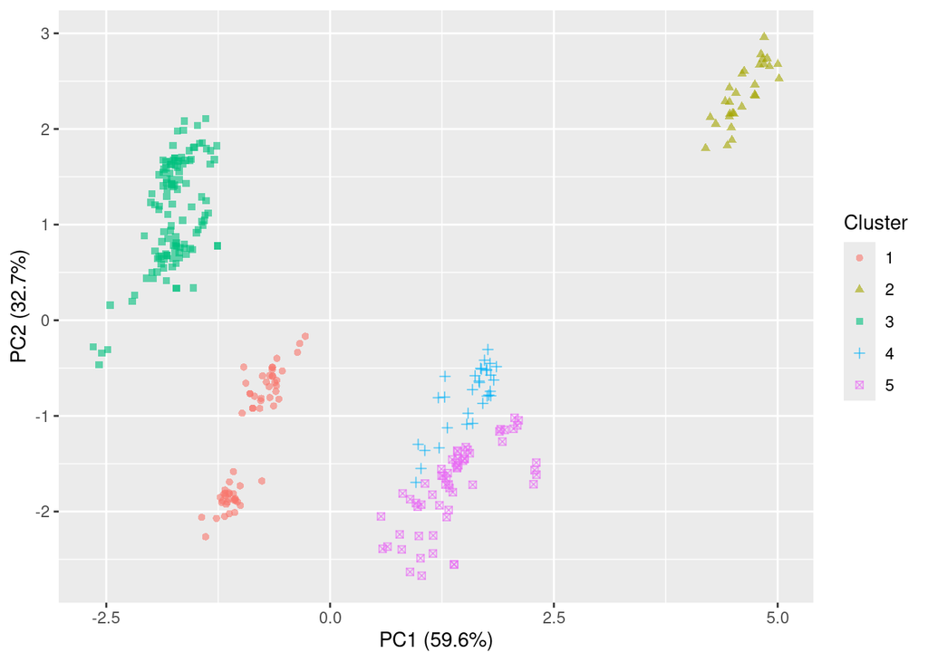

```r
pizzaPCA <- prcomp(x = PizzaScaled, center = TRUE, scale. = TRUE)
PVE <- pizzaPCA$sdev^2/sum(pizzaPCA$sdev^2)

pca_df <- as.data.frame(x = pizzaPCA$x[, 1:2])
pca_df <- pca_df %>% mutate(cluster = kmeansRes5c$cluster)

ggplot(pca_df, aes(x = PC1, y = PC2,
                   color = as.factor(cluster),
                   shape = as.factor(cluster))) +
  geom_point(alpha = 0.6) +
    labs(x = paste("PC1 (", round(100*PVE[1], digits = 1), "%)", sep = ""),
       y = paste("PC2 (", round(100*PVE[2], digits = 1), "%)", sep = ""),
       color = "Cluster",
       shape = "Cluster")
```